# Data Manipulation with R

Wenxiao Zhou

4/25/2022

# Data Manipulation with dplyr

**Transforming Data with dplyr**

```r
#Understanding the data
library(dplyr)
help(glimpse) #within dplyr package
```

```
## Help on topic 'glimpse' was found in the following packages:
##
##   Package               Library
##   dplyr                 /Library/Frameworks/R.framework/Versions/4.0/Resources/library
##   tibble                /Library/Frameworks/R.framework/Versions/4.0/Resources/library
##   pillar                /Library/Frameworks/R.framework/Versions/4.0/Resources/library
##
##
## Using the first match ...
```

```r
setwd("/Users/zhouwenxiao/Desktop/Data Manipulation with R")
counties<-readRDS("counties.rds")
#take a look at data using glimpse() function
glimpse(counties)
```

```
## Rows: 3,138
## Columns: 40
## $ census_id          <chr> "1001", "1003", "1005", "1007", "1009", "1011", "10…
## $ state              <chr> "Alabama", "Alabama", "Alabama", "Alabama", "Alabam…
## $ county             <chr> "Autauga", "Baldwin", "Barbour", "Bibb", "Blount", …
## $ region             <chr> "South", "South", "South", "South", "South", "South…
## $ metro              <chr> "Metro", "Metro", "Nonmetro", "Metro", "Metro", "No…
## $ population         <dbl> 55221, 195121, 26932, 22604, 57710, 10678, 20354, 1…
## $ men                <dbl> 26745, 95314, 14497, 12073, 28512, 5660, 9502, 5627…
## $ women              <dbl> 28476, 99807, 12435, 10531, 29198, 5018, 10852, 603…
## $ hispanic           <dbl> 2.6, 4.5, 4.6, 2.2, 8.6, 4.4, 1.2, 3.5, 0.4, 1.5, 7…
## $ white              <dbl> 75.8, 83.1, 46.2, 74.5, 87.9, 22.2, 53.3, 73.0, 57.…
## $ black              <dbl> 18.5, 9.5, 46.7, 21.4, 1.5, 70.7, 43.8, 20.3, 40.3,…
## $ native             <dbl> 0.4, 0.6, 0.2, 0.4, 0.3, 1.2, 0.1, 0.2, 0.2, 0.6, 0…
## $ asian              <dbl> 1.0, 0.7, 0.4, 0.1, 0.1, 0.2, 0.4, 0.9, 0.8, 0.3, 0…
```

[output cut: 27 more lines]

```r
#select columns
#select 'state','county','population','poverty' columns
counties %>% select(state,county,population,poverty)
```

```
## # A tibble: 3,138 x 4
##    state   county   population poverty
##    <chr>   <chr>         <dbl>   <dbl>
##  1 Alabama Autauga       55221    12.9
##  2 Alabama Baldwin      195121    13.4
##  3 Alabama Barbour       26932    26.7
##  4 Alabama Bibb          22604    16.8
##  5 Alabama Blount        57710    16.7
##  6 Alabama Bullock       10678    24.6
##  7 Alabama Butler        20354    25.4
##  8 Alabama Calhoun      116648    20.5
##  9 Alabama Chambers      34079    21.6
## 10 Alabama Cherokee      26008    19.2
## # … with 3,128 more rows
```

The `arrange()` verb sorts your data based on one or more variables. You can start with your counties selected variable, then the `pipe operator`, then `arrange()`. Inside the parentheses, put population to specify the variable you want to sort by.

```r
#arrange observations
#sort the selected table using `public_work` variable in descending order
counties_selected <- counties %>%
  select(state, county, population, private_work, public_work, self_employed)
counties_selected %>%
  arrange(desc(public_work))
```

```
## # A tibble: 3,138 x 6
##    state     county            population private_work public_work self_employed
##    <chr>     <chr>                  <dbl>        <dbl>       <dbl>         <dbl>
##  1 Hawaii    Kalawao                   85         25          64.1          10.9
##  2 Alaska    Yukon-Koyukuk Ce…       5644         33.3        61.7           5.1
##  3 Wisconsin Menominee               4451         36.8        59.1           3.7
##  4 North Da… Sioux                   4380         32.9        56.8          10.2
##  5 South Da… Todd                    9942         34.4        55             9.8
##  6 Alaska    Lake and Peninsu…       1474         42.2        51.6           6.1
##  7 Californ… Lassen                 32645         42.6        50.5           6.8
##  8 South Da… Buffalo                 2038         48.4        49.5           1.8
##  9 South Da… Dewey                   5579         34.9        49.2          14.7
## 10 Texas     Kenedy                   565         51.9        48.1           0
## # … with 3,128 more rows
```

You can use the `filter()` verb to extract only particular observations from a dataset, based on a condition. Recall that after your first verb, you can add a pipe operator, then add another verb. You can pipe any number of verbs together to transform your dataset. For example, after the `arrange()`, you could add filter state equals equals quote New York to get only counties in the state of New York. Notice that the observations are filtered, but they’re still sorted by population thanks to your arrange.

```r
#filter for conditions
#find only the counties that have a population above one million(1000000)
#and also only state of California
counties_selected %>%
  filter(population>1000000,state=='California')
```

```
## # A tibble: 9 x 6
##   state      county         population private_work public_work self_employed
##   <chr>      <chr>               <dbl>        <dbl>       <dbl>         <dbl>
## 1 California Alameda           1584983         78.7        13.8           7.4
## 2 California Contra Costa      1096068         77.5        13.6           8.7
## 3 California Los Angeles      10038388         79          11.5           9.4
## 4 California Orange            3116069         81.8        10.2           7.8
## 5 California Riverside         2298032         77.1        14.9           7.8
## 6 California Sacramento        1465832         70.8        21.8           7.3
## 7 California San Bernardino    2094769         76.4        16.7           6.7
## 8 California San Diego         3223096         77.3        14.8           7.7
## 9 California Santa Clara       1868149         84.3         9.3           6.4
```

```r
#Finally, you can combine multiple conditions together in a filter
```

```r
#filter & arrange together
counties_selected %>%
  # Filter for Texas and more than 10000 people
  filter(state=="Texas", population>10000) %>%
  # Sort in descending order of private_work
  arrange(desc(private_work))
```

```
## # A tibble: 169 x 6
##    state county  population private_work public_work self_employed
##    <chr> <chr>        <dbl>        <dbl>       <dbl>         <dbl>
##  1 Texas Gregg       123178         84.7         9.8           5.4
##  2 Texas Collin      862215         84.1        10             5.8
##  3 Texas Dallas     2485003         83.9         9.5           6.4
##  4 Texas Harris     4356362         83.4        10.1           6.3
##  5 Texas Andrews      16775         83.1         9.6           6.8
##  6 Texas Tarrant    1914526         83.1        11.4           5.4
##  7 Texas Titus        32553         82.5        10             7.4
##  8 Texas Denton      731851         82.2        11.9           5.7
##  9 Texas Ector       149557         82          11.2           6.7
## 10 Texas Moore        22281         82          11.7           5.9
## # … with 159 more rows
```

#Use `mutate()` verb to add new variables or change existing variables.

```r
#calculate the number of government employees
#within the counties data frame, unemployment is a percentage variable, same
#as public_work variable
counties_selected<-counties %>%
    select(state, county, population, public_work)
counties_selected %>%
    # add a new column public_workers with the number of people employed in public work
   mutate(public_workers=population*public_work/100) %>%
  # sort in descending order of the public_workers column
   arrange(desc(public_workers))
```

```
## # A tibble: 3,138 x 5
##    state      county         population public_work public_workers
##    <chr>      <chr>               <dbl>       <dbl>          <dbl>
##  1 California Los Angeles      10038388        11.5       1154415.
##  2 Illinois   Cook              5236393        11.5        602185.
##  3 California San Diego         3223096        14.8        477018.
##  4 Arizona    Maricopa          4018143        11.7        470123.
##  5 Texas      Harris            4356362        10.1        439993.
##  6 New York   Kings             2595259        14.4        373717.
##  7 California San Bernardino    2094769        16.7        349826.
##  8 California Riverside         2298032        14.9        342407.
##  9 California Sacramento        1465832        21.8        319551.
## 10 California Orange            3116069        10.2        317839.
## # … with 3,128 more rows
```

```r
#calculate the percentage of women in a county
counties_selected <- counties %>%
  # Select the columns state, county, population, men, and women
  select(state,county,population,men,women)
counties_selected %>%
   mutate(proportion_women=women/population)
```

```
## # A tibble: 3,138 x 6
##    state   county   population   men women proportion_women
##    <chr>   <chr>         <dbl> <dbl> <dbl>            <dbl>
##  1 Alabama Autauga       55221 26745 28476            0.516
##  2 Alabama Baldwin      195121 95314 99807            0.512
##  3 Alabama Barbour       26932 14497 12435            0.462
##  4 Alabama Bibb          22604 12073 10531            0.466
##  5 Alabama Blount        57710 28512 29198            0.506
##  6 Alabama Bullock       10678  5660  5018            0.470
##  7 Alabama Butler        20354  9502 10852            0.533
##  8 Alabama Calhoun      116648 56274 60374            0.518
##  9 Alabama Chambers      34079 16258 17821            0.523
## 10 Alabama Cherokee      26008 12975 13033            0.501
## # … with 3,128 more rows
```

Now, we can combine all four verbs together `select()`,`mutate()`,`filter()`,`arrange()`

```r
counties %>%
  # Select the five columns
   select(state,county,population,men,women) %>%
  # Add the proportion_men variable
  mutate(proportion_men=men/population) %>%
  # Filter for population of at least 10,000
  filter(population>=10000) %>%
  # Arrange proportion of men in descending order
  arrange(desc(proportion_men))
```

```
## # A tibble: 2,437 x 6
##    state      county         population   men women proportion_men
##    <chr>      <chr>               <dbl> <dbl> <dbl>          <dbl>
##  1 Virginia   Sussex              11864  8130  3734          0.685
##  2 California Lassen              32645 21818 10827          0.668
##  3 Georgia    Chattahoochee       11914  7940  3974          0.666
##  4 Louisiana  West Feliciana      15415 10228  5187          0.664
##  5 Florida    Union               15191  9830  5361          0.647
##  6 Texas      Jones               19978 12652  7326          0.633
##  7 Missouri   DeKalb              12782  8080  4702          0.632
##  8 Texas      Madison             13838  8648  5190          0.625
##  9 Virginia   Greensville         11760  7303  4457          0.621
## 10 Texas      Anderson            57915 35469 22446          0.612
## # … with 2,427 more rows
```

**Aggregating Data**  
To `filter` or `sort` for observations you’re interested in, and to `add new variables with the mutate verb` are the work at the same level as the initial data, where every observation corresponds to one US county.  
Now you need more about the summary, which is called as aggregate data: to take many observations and summarize them into one. This is a common data science strategy for making data manageable and interpreted.

```r
#counting by region
#Finding the number of counties in each region
counties_selected <- counties %>%
  select(county, region, state, population, citizens)
counties %>%
   count()
```

```
## # A tibble: 1 x 1
##       n
##   <int>
## 1  3138
```

```r
counties %>%
  count(state)
```

```
## # A tibble: 50 x 2
##    state           n
##  * <chr>       <int>
##  1 Alabama        67
##  2 Alaska         28
##  3 Arizona        15
##  4 Arkansas       75
##  5 California     58
##  6 Colorado       64
##  7 Connecticut     8
##  8 Delaware        3
##  9 Florida        67
## 10 Georgia       159
## # … with 40 more rows
```

```r
counties_selected %>%
  count(region,sort=TRUE)
```

```
## # A tibble: 4 x 2
##   region            n
##   <chr>         <int>
## 1 South          1420
## 2 North Central  1054
## 3 West            447
## 4 Northeast       217
```

```r
#Count the number of counties in each state, weighted based on the `citizens` column, and sorted in descending order
counties_selected <- counties %>%
  select(county, region, state, population, citizens) %>%
  count(state,wt=citizens,sort=TRUE)
counties_selected
```

```
## # A tibble: 50 x 2
##    state                 n
##    <chr>             <dbl>
##  1 California     24280349
##  2 Texas          16864864
##  3 Florida        13933052
##  4 New York       13531404
##  5 Pennsylvania    9710416
##  6 Illinois        8979999
##  7 Ohio            8709050
##  8 Michigan        7380136
##  9 North Carolina  7107998
## 10 Georgia         6978660
## # … with 40 more rows
```

Mutating and counting  
Use multiple verbs together to answer increasing complicated questions of your data.

```r
#walk: which offers a percentage of people in each county that walk to work, to add a new column and count based on it
counties_selected <- counties %>%
  select(county, region, state, population, walk)
counties_selected %>%
  # Add population_walk containing the total number of people who walk to work
  mutate(population_walk = population * walk / 100) %>%
  # Count weighted by the new column, sort in descending order
  count(state, wt = population_walk, sort = TRUE)
```

```
## # A tibble: 50 x 2
##    state                n
##    <chr>            <dbl>
##  1 New York      1237938.
##  2 California    1017964.
##  3 Pennsylvania   505397.
##  4 Texas          430783.
##  5 Illinois       400346.
##  6 Massachusetts  316765.
##  7 Florida        284723.
##  8 New Jersey     273047.
##  9 Ohio           266911.
## 10 Washington     239764.
## # … with 40 more rows
```

`count()` is a special case of a more general set of verbs: `group_by() and summarize()`.  
The `summarize()` verb takes many observations and turns them into one observation.  
&Newline; &Newline;

```r
#summarizing
counties_selected <- counties %>%
  select(county, population, income, unemployment)
#summarize the counties dataset to find the following columns:
#min_population (smallest population)
#max_unemployment (maximum unemployment)
#average_income (mean of the income variable)
counties_selected %>%
  # Summarize to find minimum population, maximum unemployment, and average income
  summarize(min_population=min(population),
            max_unemployment=max(unemployment),
            average_income=mean(income))
```

```
## # A tibble: 1 x 3
##   min_population max_unemployment average_income
##            <dbl>            <dbl>          <dbl>
## 1             85             29.4         46832.
```

```r
#summarize by state
#land_area: shows the land area in square miles
#summarize both population and land area by state, and
#find the density (in people per square miles)
counties_selected <- counties %>%
  select(state,county, population, land_area)
counties_selected %>%
  group_by(state) %>%
  summarize(total_area = sum(land_area),
            total_population = sum(population)) %>%
  # Add a density column (people per square mile)
  mutate(density=total_population/total_area) %>%
  # Sort by density in descending order
  arrange(desc(density))
```

```
## # A tibble: 50 x 4
##    state         total_area total_population density
##    <chr>              <dbl>            <dbl>   <dbl>
##  1 New Jersey         7354.          8904413   1211.
##  2 Rhode Island       1034.          1053661   1019.
##  3 Massachusetts      7800.          6705586    860.
##  4 Connecticut        4842.          3593222    742.
##  5 Maryland           9707.          5930538    611.
##  6 Delaware           1949.           926454    475.
##  7 New York          47126.         19673174    417.
##  8 Florida           53625.         19645772    366.
##  9 Pennsylvania      44743.         12779559    286.
## 10 Ohio              40861.         11575977    283.
## # … with 40 more rows
```

```r
#summarize by state and region
counties_selected <- counties %>%
  select(region, state, county, population)
counties_selected %>%
  # Group and summarize to find the total population
  group_by(region, state) %>%
  summarize(total_pop = sum(population)) %>%
# Calculate the average_pop and median_pop columns
  # Notice that the tibble is still grouped by region, use another
  # summarize() step to add more columns under this grouping

  #the average state population in each region
  #the median state population in each region
  summarize(average_pop=mean(total_pop),
            median_pop=median(total_pop))
```

```
## # A tibble: 4 x 3
##   region        average_pop median_pop
## * <chr>               <dbl>      <dbl>
## 1 North Central    5627687.    5580644
## 2 Northeast        6221058.    3593222
## 3 South            7370486     4804098
## 4 West             5722755.    2798636
```

```r
#The final result includes four regions' average population and median population by two columns
```

`top_n()` is helpful to keep the most extreme observations from each group  
Just like `summarize()`, top_n() operates on a grouped table. The function takes two arguments: the number of observations you want from each group  
the column you want to weight by  
`top_n()` is often used when creating graphs, where we’re interested in pulling the extreme examples to include in the visualization.

```r
#selecting a county from each region
counties_selected <- counties %>%
  select(region, state, county, metro, population, walk)
#Find the county in each region with the highest percentage of citizens who walk to work
counties_selected %>%
  group_by(region) %>%
  top_n(1,walk)
```

```
## # A tibble: 4 x 6
## # Groups:   region [4]
##   region        state        county                 metro    population  walk
##   <chr>         <chr>        <chr>                  <chr>         <dbl> <dbl>
## 1 West          Alaska       Aleutians East Borough Nonmetro       3304  71.2
## 2 Northeast     New York     New York               Metro       1629507  20.7
## 3 North Central North Dakota McIntosh               Nonmetro       2759  17.5
## 4 South         Virginia     Lexington city         Nonmetro       7071  31.7
```

```r
#finding the highest income state in each region
#group_by(), summarize(), top_n()
counties_selected <- counties %>%
  select(region, state, county, population, income)
counties_selected %>%
  group_by(region, state) %>%
  # Calculate average income
  summarize(average_income=mean(income)) %>%
  # Find the highest income state in each region
  top_n(1,average_income)
```

```
## # A tibble: 4 x 3
## # Groups:   region [4]
##   region        state        average_income
##   <chr>         <chr>                 <dbl>
## 1 North Central North Dakota         55575.
## 2 Northeast     New Jersey           73014.
## 3 South         Maryland             69200.
## 4 West          Alaska               65125.
```

```r
# From our results, we can see that the New Jersey in the Northeast is the state with the highest average_income of 73014.
```

When you group by multiple columns and then summarize, it’s important to remember that the summarize “peels off” one of the groups, but leaves the rest on.  
For example, if you group_by(X, Y) then summarize, the result will still be grouped by X

```r
#Using summarize, top_n,count together
#Answer the following questions:
# In How many states do more people live in metro areas than non-metro areas?
counties_selected <- counties %>%
  select(state, metro, population)
counties_selected %>%
  # Find the total population for each combination of state and metro
  group_by(state, metro) %>%
  summarize(total_pop = sum(population)) %>%
  # Extract the most populated row for each state
  top_n(1, total_pop) %>%
  # Count the states with more people in Metro or Nonmetro areas
  ungroup()   %>%
  # (firstly, since most data operations are done on groups defined by variables. group_by() takes an existing table and converts it into a grouped tbl where operations are performed "by group". ungroup() removes grouping.)
  count(metro)
```

```
## # A tibble: 2 x 2
##   metro        n
## * <chr>    <int>
## 1 Metro       44
## 2 Nonmetro     6
```

**Selecting and Transforming Data**

```r
#using a colon (:) can select variables that are consecutive
counties %>%
  # Select state, county, population, and industry-related columns
  select(state,county,population,professional:production) %>%
  # Arrange service in descending order
  arrange(desc(service))
```

```
## # A tibble: 3,138 x 8
##    state   county population professional service office construction production
##    <chr>   <chr>       <dbl>        <dbl>   <dbl>  <dbl>        <dbl>      <dbl>
##  1 Missis… Tunica      10477         23.9    36.6   21.5          3.5       14.5
##  2 Texas   Kinney       3577         30      36.5   11.6         20.5        1.3
##  3 Texas   Kenedy        565         24.9    34.1   20.5         20.5        0
##  4 New Yo… Bronx     1428357         24.3    33.3   24.2          7.1       11
##  5 Texas   Brooks       7221         19.6    32.4   25.3         11.1       11.5
##  6 Colora… Fremo…      46809         26.6    32.2   22.8         10.7        7.6
##  7 Texas   Culbe…       2296         20.1    32.2   24.2         15.7        7.8
##  8 Califo… Del N…      27788         33.9    31.5   18.8          8.9        6.8
##  9 Minnes… Mahno…       5496         26.8    31.5   18.7         13.1        9.9
## 10 Virgin… Lanca…      11129         30.3    31.2   22.8          8.1        7.6
## # … with 3,128 more rows
```

```r
#use starts_with(), ends_with(), which finds the columns that end with a particular string
counties %>%
  # Select the state, county, population, and those ending with "work"
  select(state,county,population,ends_with("work")) %>%
  # Filter for counties that have at least 50% of people engaged in public work
  filter(public_work>=50)
```

```
## # A tibble: 7 x 6
##   state      county              population private_work public_work family_work
##   <chr>      <chr>                    <dbl>        <dbl>       <dbl>       <dbl>
## 1 Alaska     Lake and Peninsula…       1474         42.2        51.6         0.2
## 2 Alaska     Yukon-Koyukuk Cens…       5644         33.3        61.7         0
## 3 California Lassen                   32645         42.6        50.5         0.1
## 4 Hawaii     Kalawao                     85         25          64.1         0
## 5 North Dak… Sioux                     4380         32.9        56.8         0.1
## 6 South Dak… Todd                      9942         34.4        55           0.8
## 7 Wisconsin  Menominee                 4451         36.8        59.1         0.4
```

`rename()` verb & `select()` verb: Notice the difference between select and rename. In select you need to name all the columns you want to keep along with renaming one or more of them. With rename, you can just pick one column whose name you want to change. The verb you choose will depend on your position within an analysis.

```r
counties %>%
   select(state,county,population,unemployment_rate=unemployment)
```

```
## # A tibble: 3,138 x 4
##    state   county   population unemployment_rate
##    <chr>   <chr>         <dbl>             <dbl>
##  1 Alabama Autauga       55221               7.6
##  2 Alabama Baldwin      195121               7.5
##  3 Alabama Barbour       26932              17.6
##  4 Alabama Bibb          22604               8.3
##  5 Alabama Blount        57710               7.7
##  6 Alabama Bullock       10678              18
##  7 Alabama Butler        20354              10.9
##  8 Alabama Calhoun      116648              12.3
##  9 Alabama Chambers      34079               8.9
## 10 Alabama Cherokee      26008               7.9
## # … with 3,128 more rows
```

```r
counties %>%
   select(state,county,population,unemployment)  %>%
   rename(unemployment_rate=unemployment)
```

```
## # A tibble: 3,138 x 4
##    state   county   population unemployment_rate
##    <chr>   <chr>         <dbl>             <dbl>
##  1 Alabama Autauga       55221               7.6
##  2 Alabama Baldwin      195121               7.5
##  3 Alabama Barbour       26932              17.6
##  4 Alabama Bibb          22604               8.3
##  5 Alabama Blount        57710               7.7
##  6 Alabama Bullock       10678              18
##  7 Alabama Butler        20354              10.9
##  8 Alabama Calhoun      116648              12.3
##  9 Alabama Chambers      34079               8.9
## 10 Alabama Cherokee      26008               7.9
## # … with 3,128 more rows
```

```r
#renaming a column after counting
counties %>%
  # Count the number of counties in each state
  count(state) %>%
  # Rename the n column to num_counties
  rename(num_counties=n)
```

```
## # A tibble: 50 x 2
##    state       num_counties
##  * <chr>              <int>
##  1 Alabama               67
##  2 Alaska                28
##  3 Arizona               15
##  4 Arkansas              75
##  5 California            58
##  6 Colorado              64
##  7 Connecticut            8
##  8 Delaware               3
##  9 Florida               67
## 10 Georgia              159
## # … with 40 more rows
```

```r
#renaming a column as part of a select
counties %>%
  # Select state, county, and poverty as poverty_rate
 select(state,county,poverty_rate=poverty)
```

```
## # A tibble: 3,138 x 3
##    state   county   poverty_rate
##    <chr>   <chr>           <dbl>
##  1 Alabama Autauga          12.9
##  2 Alabama Baldwin          13.4
##  3 Alabama Barbour          26.7
##  4 Alabama Bibb             16.8
##  5 Alabama Blount           16.7
##  6 Alabama Bullock          24.6
##  7 Alabama Butler           25.4
##  8 Alabama Calhoun          20.5
##  9 Alabama Chambers         21.6
## 10 Alabama Cherokee         19.2
## # … with 3,128 more rows
```

`transmute()` as a combination of select & mutate  
It returns a subset of columns that are transformed and changed.

&Newline; A summary of four verbs for changing and keeping variables:  
`select()`:can’t change values, keeps only specified variables  
`rename()`:can’t change values, keeps other variables  
`mutate()`:can change values, keeps other variables  
`transmute()`:can change values, keeps only specified variables

(If you would like to calculate new columns while dropping other columns, use `transmute()`)

```r
#Using transmute
counties %>%
  # Keep the state, county, and populations columns, and add a density column
  transmute(state,county,population,density=population/land_area) %>%
  # Filter for counties with a population greater than one million
  filter(population>1000000) %>%
  # Sort density in ascending order
  arrange(density)
```

```
## # A tibble: 41 x 4
##    state      county         population density
##    <chr>      <chr>               <dbl>   <dbl>
##  1 California San Bernardino    2094769    104.
##  2 Nevada     Clark             2035572    258.
##  3 California Riverside         2298032    319.
##  4 Arizona    Maricopa          4018143    437.
##  5 Florida    Palm Beach        1378806    700.
##  6 California San Diego         3223096    766.
##  7 Washington King              2045756    967.
##  8 Texas      Travis            1121645   1133.
##  9 Florida    Hillsborough      1302884   1277.
## 10 Florida    Orange            1229039   1360.
## # … with 31 more rows
```

```r
#Choosing among the four verbs
# Change the name of the unemployment column
counties %>%
  rename(unemployment_rate = unemployment)
```

```
## # A tibble: 3,138 x 40
##    census_id state   county  region metro  population   men women hispanic white
##    <chr>     <chr>   <chr>   <chr>  <chr>       <dbl> <dbl> <dbl>    <dbl> <dbl>
##  1 1001      Alabama Autauga South  Metro       55221 26745 28476      2.6  75.8
##  2 1003      Alabama Baldwin South  Metro      195121 95314 99807      4.5  83.1
##  3 1005      Alabama Barbour South  Nonme…      26932 14497 12435      4.6  46.2
##  4 1007      Alabama Bibb    South  Metro       22604 12073 10531      2.2  74.5
##  5 1009      Alabama Blount  South  Metro       57710 28512 29198      8.6  87.9
##  6 1011      Alabama Bullock South  Nonme…      10678  5660  5018      4.4  22.2
##  7 1013      Alabama Butler  South  Nonme…      20354  9502 10852      1.2  53.3
##  8 1015      Alabama Calhoun South  Metro      116648 56274 60374      3.5  73
##  9 1017      Alabama Chambe… South  Nonme…      34079 16258 17821      0.4  57.3
## 10 1019      Alabama Cherok… South  Nonme…      26008 12975 13033      1.5  91.7
## # … with 3,128 more rows, and 30 more variables: black <dbl>, native <dbl>,
## #   asian <dbl>, pacific <dbl>, citizens <dbl>, income <dbl>, income_err <dbl>,
## #   income_per_cap <dbl>, income_per_cap_err <dbl>, poverty <dbl>,
## #   child_poverty <dbl>, professional <dbl>, service <dbl>, office <dbl>,
## #   construction <dbl>, production <dbl>, drive <dbl>, carpool <dbl>,
## #   transit <dbl>, walk <dbl>, other_transp <dbl>, work_at_home <dbl>,
## #   mean_commute <dbl>, employed <dbl>, private_work <dbl>, public_work <dbl>,
## #   self_employed <dbl>, family_work <dbl>, unemployment_rate <dbl>,
## #   land_area <dbl>
```

```r
# Keep the state and county columns, and the columns containing poverty
counties %>%
  select(state, county, contains("poverty"))
```

```
## # A tibble: 3,138 x 4
##    state   county   poverty child_poverty
##    <chr>   <chr>      <dbl>         <dbl>
##  1 Alabama Autauga     12.9          18.6
##  2 Alabama Baldwin     13.4          19.2
##  3 Alabama Barbour     26.7          45.3
##  4 Alabama Bibb        16.8          27.9
##  5 Alabama Blount      16.7          27.2
##  6 Alabama Bullock     24.6          38.4
##  7 Alabama Butler      25.4          39.2
##  8 Alabama Calhoun     20.5          31.6
##  9 Alabama Chambers    21.6          37.2
## 10 Alabama Cherokee    19.2          30.1
## # … with 3,128 more rows
```

```r
# Calculate the fraction_women column without dropping the other columns
counties %>%
  mutate(fraction_women = women / population)
```

```
## # A tibble: 3,138 x 41
##    census_id state   county  region metro  population   men women hispanic white
##    <chr>     <chr>   <chr>   <chr>  <chr>       <dbl> <dbl> <dbl>    <dbl> <dbl>
##  1 1001      Alabama Autauga South  Metro       55221 26745 28476      2.6  75.8
##  2 1003      Alabama Baldwin South  Metro      195121 95314 99807      4.5  83.1
##  3 1005      Alabama Barbour South  Nonme…      26932 14497 12435      4.6  46.2
##  4 1007      Alabama Bibb    South  Metro       22604 12073 10531      2.2  74.5
##  5 1009      Alabama Blount  South  Metro       57710 28512 29198      8.6  87.9
##  6 1011      Alabama Bullock South  Nonme…      10678  5660  5018      4.4  22.2
##  7 1013      Alabama Butler  South  Nonme…      20354  9502 10852      1.2  53.3
##  8 1015      Alabama Calhoun South  Metro      116648 56274 60374      3.5  73
##  9 1017      Alabama Chambe… South  Nonme…      34079 16258 17821      0.4  57.3
## 10 1019      Alabama Cherok… South  Nonme…      26008 12975 13033      1.5  91.7
## # … with 3,128 more rows, and 31 more variables: black <dbl>, native <dbl>,
## #   asian <dbl>, pacific <dbl>, citizens <dbl>, income <dbl>, income_err <dbl>,
## #   income_per_cap <dbl>, income_per_cap_err <dbl>, poverty <dbl>,
## #   child_poverty <dbl>, professional <dbl>, service <dbl>, office <dbl>,
## #   construction <dbl>, production <dbl>, drive <dbl>, carpool <dbl>,
## #   transit <dbl>, walk <dbl>, other_transp <dbl>, work_at_home <dbl>,
## #   mean_commute <dbl>, employed <dbl>, private_work <dbl>, public_work <dbl>,
## #   self_employed <dbl>, family_work <dbl>, unemployment <dbl>,
## #   land_area <dbl>, fraction_women <dbl>
```

```r
# Keep only the state, county, and employment_rate columns
counties %>%
  transmute(state, county, employment_rate = employed / population)
```

```
## # A tibble: 3,138 x 3
##    state   county   employment_rate
##    <chr>   <chr>              <dbl>
##  1 Alabama Autauga            0.434
##  2 Alabama Baldwin            0.441
##  3 Alabama Barbour            0.319
##  4 Alabama Bibb               0.367
##  5 Alabama Blount             0.384
##  6 Alabama Bullock            0.362
##  7 Alabama Butler             0.384
##  8 Alabama Calhoun            0.406
##  9 Alabama Chambers           0.402
## 10 Alabama Cherokee           0.390
## # … with 3,128 more rows
```

**Case Study: The babynames Data Set**

```r
#Understanding the data
babynames<-readRDS("babynames.rds")
#take a look at data using glimpse() function
library(dplyr)
glimpse(babynames)
```

```
## Rows: 332,595
## Columns: 3
## $ year   <dbl> 1880, 1880, 1880, 1880, 1880, 1880, 1880, 1880, 1880, 1880, 188…
## $ name   <chr> "Aaron", "Ab", "Abbie", "Abbott", "Abby", "Abe", "Abel", "Abiga…
## $ number <int> 102, 5, 71, 5, 6, 50, 9, 12, 27, 81, 21, 652, 24, 23, 104, 14, …
```

```r
babynames %>%
  # Filter for the year 1990
  filter(year==1990) %>%
  # Sort the number column in descending order
  arrange(desc(number))
```

```
## # A tibble: 21,223 x 3
##     year name        number
##    <dbl> <chr>        <int>
##  1  1990 Michael      65560
##  2  1990 Christopher  52520
##  3  1990 Jessica      46615
##  4  1990 Ashley       45797
##  5  1990 Matthew      44925
##  6  1990 Joshua       43382
##  7  1990 Brittany     36650
##  8  1990 Amanda       34504
##  9  1990 Daniel       33963
## 10  1990 David        33862
## # … with 21,213 more rows
```

```r
#using top_n with babynames to find the most common name in each year
babynames %>%
  group_by(year) %>%
  top_n(1,number)
```

```
## # A tibble: 28 x 3
## # Groups:   year [28]
##     year name  number
##    <dbl> <chr>  <int>
##  1  1880 John    9701
##  2  1885 Mary    9166
##  3  1890 Mary   12113
##  4  1895 Mary   13493
##  5  1900 Mary   16781
##  6  1905 Mary   16135
##  7  1910 Mary   22947
##  8  1915 Mary   58346
##  9  1920 Mary   71175
## 10  1925 Mary   70857
## # … with 18 more rows
```

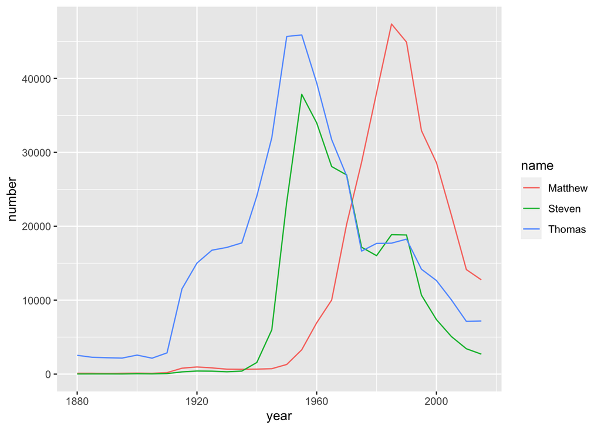

```r
selected_names <- babynames %>%
  # Filter for the names Steven, Thomas, and Matthew
  filter(name %in% c('Steven','Thomas','Matthew'))
library(ggplot2)
selected_names <- babynames %>%
  # Filter for the names Steven, Thomas, and Matthew
  filter(name %in% c("Steven", "Thomas", "Matthew"))

# Plot the names using a different color for each name
ggplot(selected_names, aes(x = year, y = number, color = name)) +
  geom_line()
```

Grouped mutate:  
Just like `group by` and summarize work well together, `group by and mutate` are a great pair. The `group by` tells dplyr that we only want to add up within each year. Then, as a `mutate`, it creates a new column called year-underscore-total, with the total number of people born in that year in this dataset.